# Preliminary-Analysis-Questionnaires

# Distribution of the samples

Let us first look at the total number of Participants (P), percentage of village, fishing gear, and fishing experience in the data set.

Total number of P:

80

We have sampled four fishing villages with the same frequency:

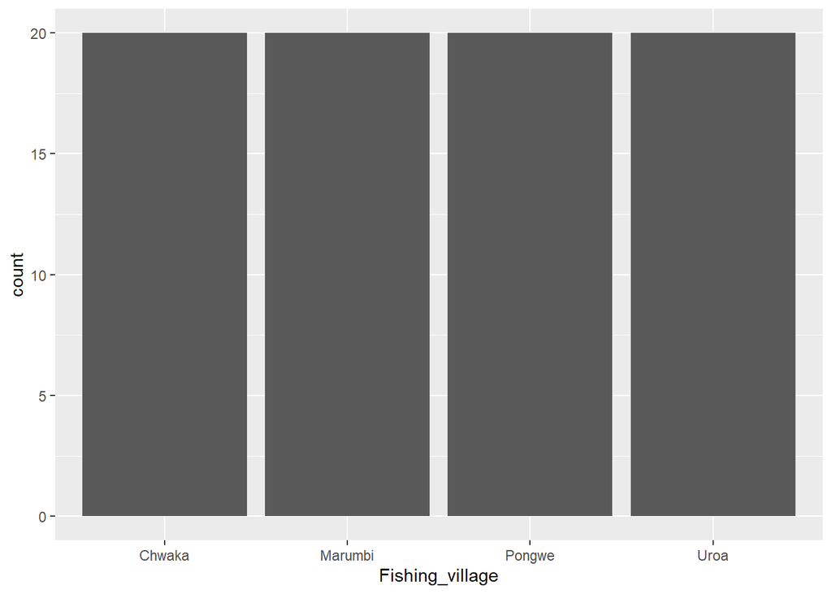

This is the pecentage of each gear represented in the data set:

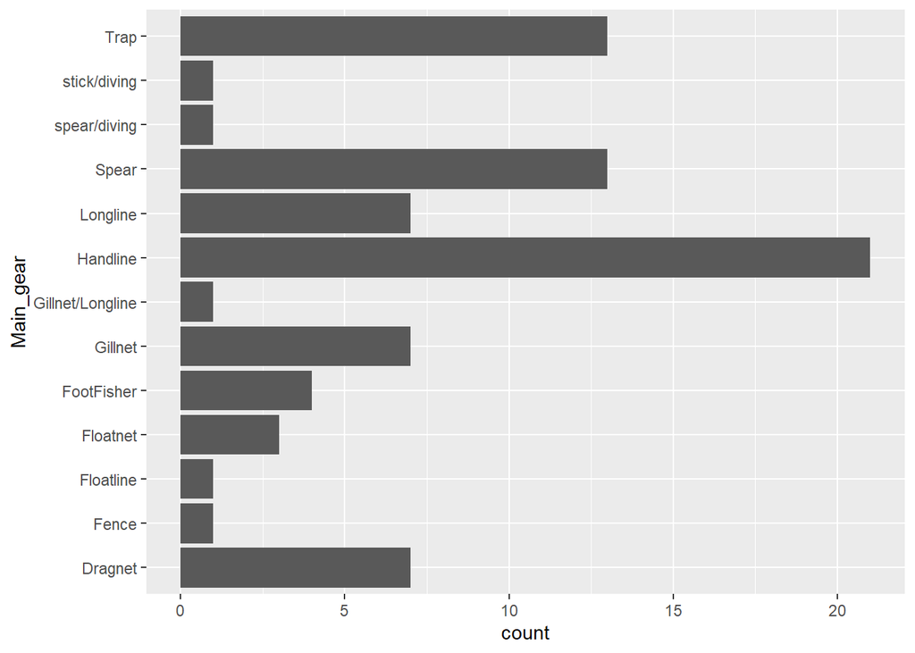

This is not evenly distributed. We actually wanted such a percentage:

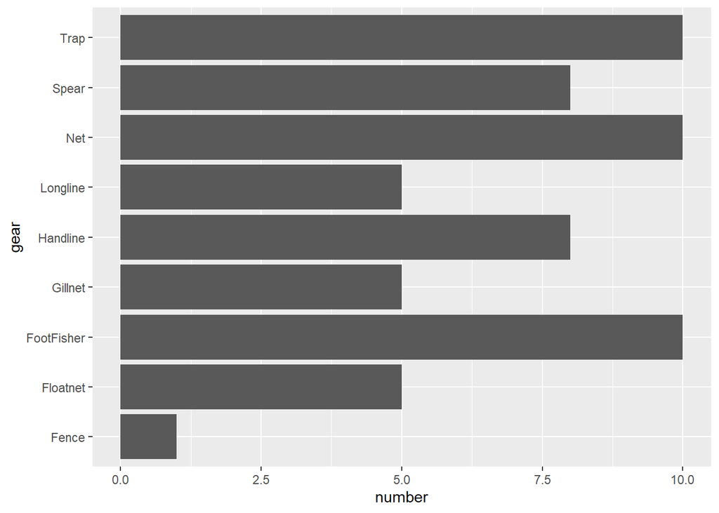

Most important let us look at the fishing experience in years of the fishers.

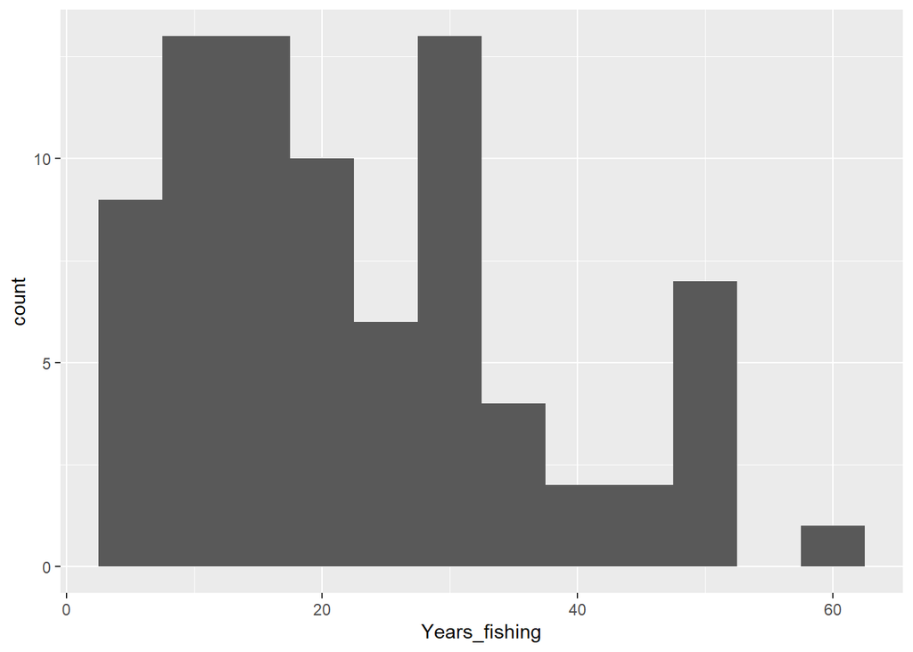

Many P have less than 20 years experience. Originally, I said, we want to have Ps that have an experience of 20 or more years. Because the model year is 2014, I decided to take out all Ps with less than 15 years of fishing. Note that asking the fisher about their catch 10, 20, 30, etc. years ago did not work according to the interviewers. Instead they asked the Ps about the current year 2021 (Sasa), the year when they started (Aliopanza) and the time in between (Kati kati). In the following I only use the starting year and the current year.

# Analysis steps

The following will depict how I treat the data and finally calculate a C2021/Cstarting ratio for each species and each participant:

## STEP 1: Extract expert fishers

As said, we only look at those fisher with an experience of more than 15 years.

This reduces the number of 80 Ps to 58.

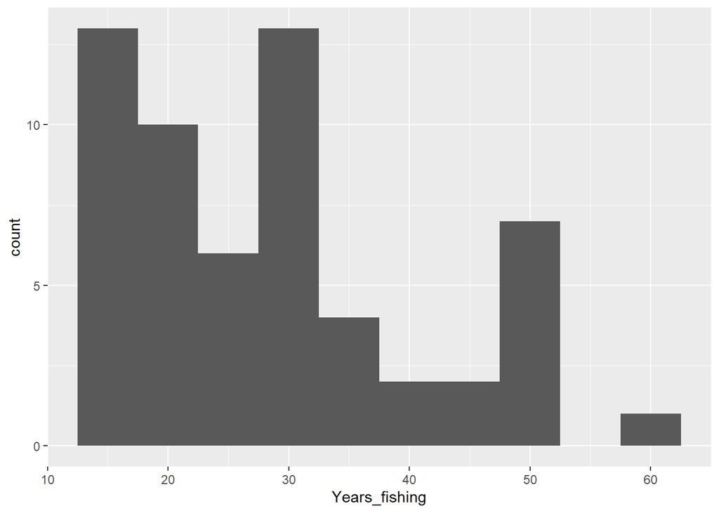

## STEP 2: Checking whether the fisher always fish in Chwaka village

```r
t <- table(totCExp$Chwaka)
```

## STEP 3: Check if the fishing hours change over time

We check which of the fisher increased or decreased their fishing effort. Surprisingly, there are only a few Ps:

```
##            Id      Time Time_year Gear_used Duration_fishing_trip
## 7    OH0213U3      Sasa      2021  Floatnet                     7
## 9    OH0213U3 Aliopanza      1971  Floatnet                     5
## 19   OH0214C7      Sasa      2021  Longline                     5
## 21   OH0214C7 Aliopanza      2001  Longline                   1.5
## 34  OH0220M12      Sasa      2021      Trap                     3
## 36  OH0220M12 Aliopanza      1991      Trap                     5
## 64   NS0213U2      Sasa      2021   Dragnet                     8
## 66   NS0213U2 Aliopanza      1970   Dragnet                     9
## 67   NS0213U3      Sasa      2021  Handline                   4.5
## 69   NS0213U3 Aliopanza      2006  Handline                   5.5
## 118 NS0221P20      Sasa      2021  Handline                     5
## 120 NS0221P20 Aliopanza      1971  Handline                     6
```

Only 6 of the 58 fisher changed the number of hours spent fishing. Note that we don’t look at the days spent fishing as we ask the fisher for their catch per fishing day.

I now simply calculate the ratio between the hours spent 2021 (Sasa) and when the fisher started (Aliopanza) and add it to the data frame so that we can adjust the catch per species from 2021 by this ratio.

```
## [1]        NA 1.4000000 3.3333333 0.6000000 0.8888889 0.8181818 0.8333333
```

## STEP 4: Check if the fisher reports on individual catch or on collective catch.

Another important point to consider when calculating the ratio between the historical and the current catch is that not all fisher fish alone. Some do it in a crew/company and thus might not be able to report on their personal catch.

Note that this would only affect our estimate if we first calculate the catch per fisher for each species, then calculate the median and then use the median to calculate a ratio. For the moment, I calculate a ratio between current and historical catch for each fisher and species and only later calculate the median.

However, we might change this procedure and so I already divide the catch per species by the number of fisher.

Also note that it is likely that the number of fisher has changed over time but unfortunately we don’t ask this. :-(

## STEP 5: Check if the gear has changed between 2021 and the starting year.

I checked if the gear has changed for any P over time. Which is not the case.

The interviewer Nuru forgot to note down the gear for all periods. I will ask her. Other than this, all Ps fish with the same year in 2021 and when they started.

## STEP 6: Check if the fisher always fished in Chwaka.

We check if the fisherfished outside of Chwaka during a period of his life.

```
##           Id Interviewer_name Years_fishing Years_fishing_Chwaka
## 22  NS0213U2  Nuru Said Salum            51                   50
## 34 NS0220M14  Nuru Said Salum            20                   10
## 35 NS0220M15  Nuru Said Salum            20                   10
## 38 NS0221P18  Nuru Said Salum            30                   25
```

## STEP 7: Remove the year in-between (Kati_kati)

I decided to only look at the starting and current year, because this is what we need to calculate: the ratio between B/Bunfished. Another option, however, could be to actually try making a time-series for each species.

## STEP 8: Correct the catch for effort change and fisher number

As mentioned above I correct the catch per species by the number of fisher and the change in fishing effort.

## STEP 10: Calculate the median for the ratio of each species

Now that we have the change in catch for each species and P as a ratio, we calculate the median for each species. I noted 7 Ps (from two differen interviewers) that supposedly reported much higher catches in 2021 than when they first started. That seems odd. For the moment I simply remove them and I have asked the interviewers to cross-check with their data sheets.

# Visualize the preliminary analysis

In the following I will plot the C/Chistorical ratios and the median for each species and P over the Ps fishing experience (years).

## Key species

These species are modelled as monospecies groups in Ecopath

```
##  [1] "Id"              "Time"            "Time_year"       "Species"
##  [5] "Gear"            "Catch"           "Unit"            "Unit2"
##  [9] "Effort_change"   "Number_fisher"   "Catch_corrected" "Catch_aliopanza"
## [13] "Years_fishing"   "Ratio"           "Ratio_median"
```

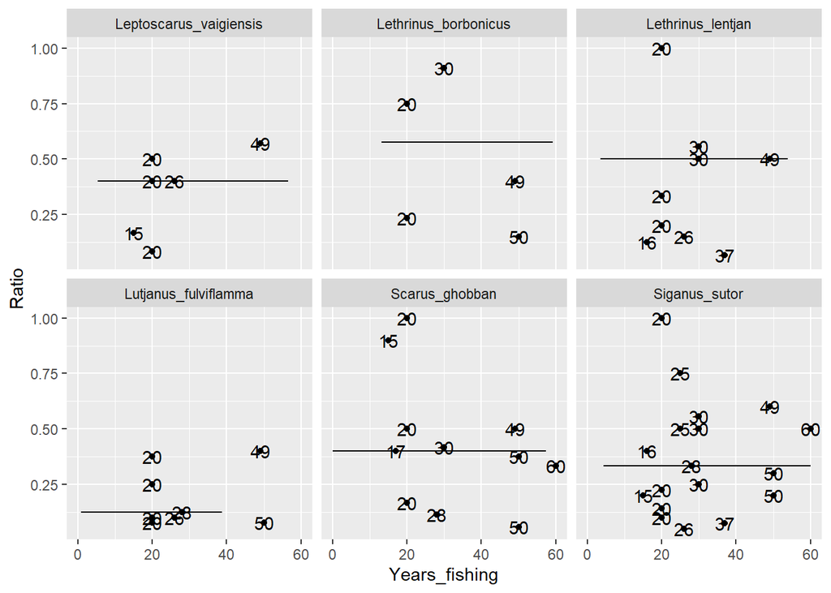

Is it the same fisher that reports no changes?

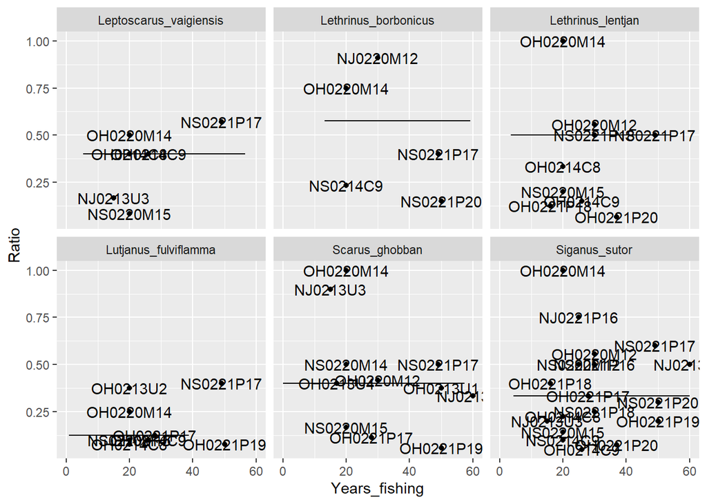

With what type of gear does this fisher fish?

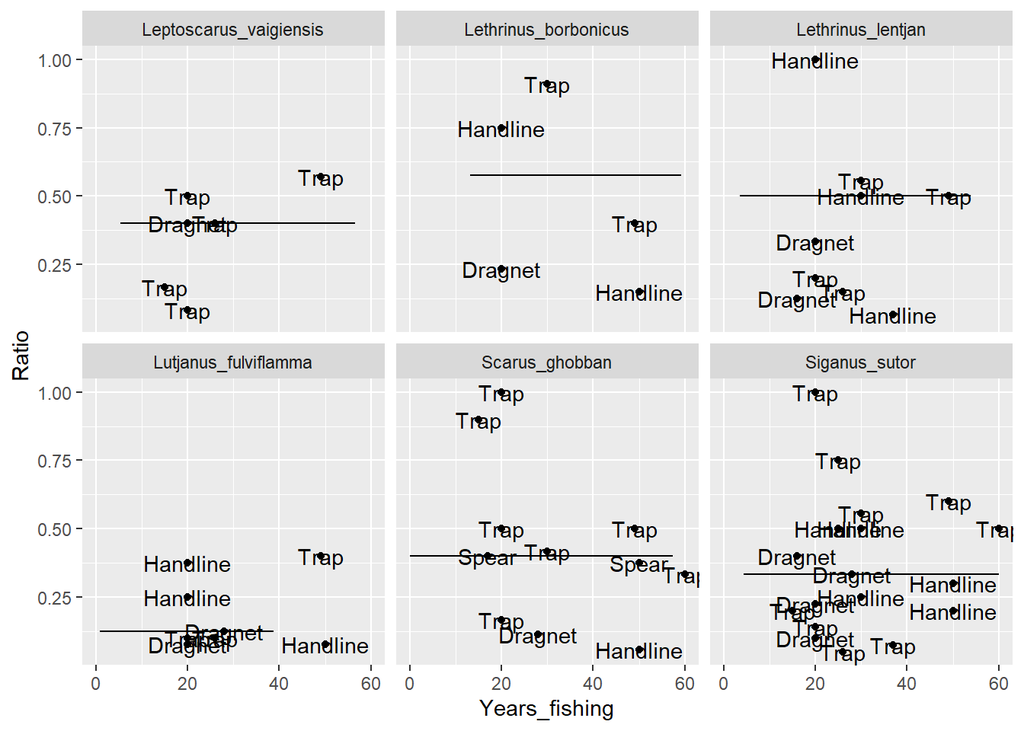

We see no real pattern. The answeres also diverge quiet a bit.

## Invertebrates

I have 4 fished invertebrate groups: Crabs&Lobsters, Squids, Octopus, and Snails

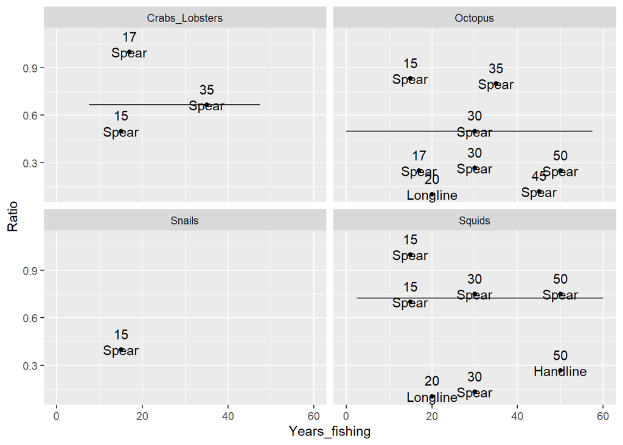

Octopus and Squids should be enough data points. The other groups not. Again no real pattern and the range is high.

## Carnivore fish

The species displayed below are the major contributors to the carnviorous fish functional group in Ecopath.

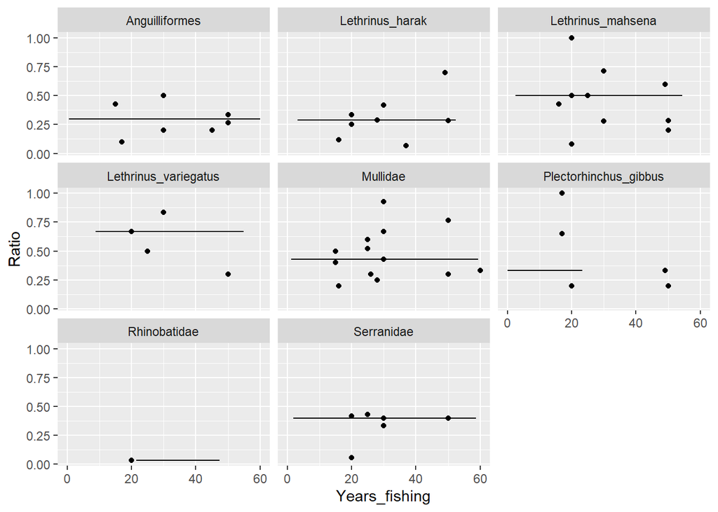

Sample size of most species, except Lethrinus variegatus and Rhinobatidae, is ok. The groups with enough sample size contribute over 60 % to carnivorous fish. So I could set a v using this information. Serranidae is the only one that seems to be very consistent… I am wondering how I will combine this information about the C/Chistorical into one B/Bunfished.

## Herbivore fish

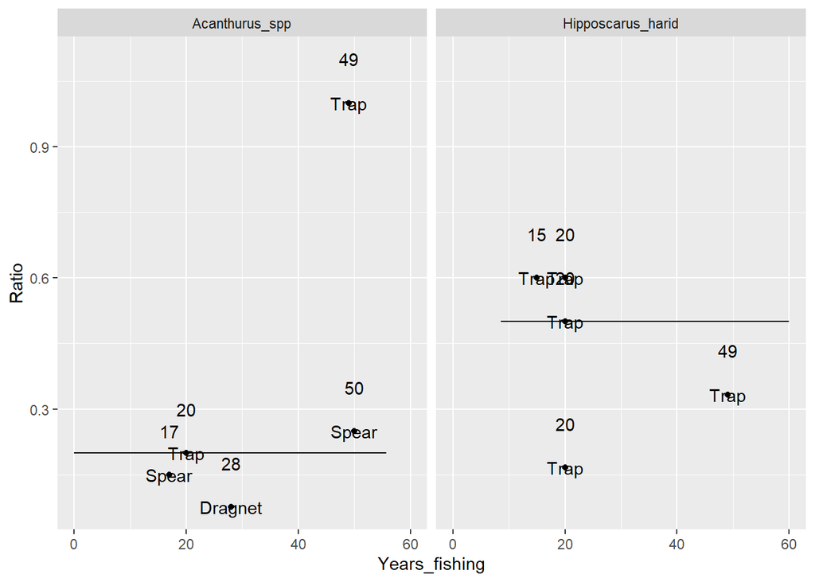

Small sample size but I could use it. Except for one P the range is much narrower.

# Points for discussion

1. Would like to discuss the sample size with you
2. How to treat the different fishing years for each P?
3. Because I calculate a ratio of C/Chistorical for each fisher, I do not worry about the units.
4. How to combined the information from the different species/group of each functional group?
5. Should we sample again?